# ESTUDIO DEL SECTOR TIC EN ANDALUCÍA

Visión de conjunto

## Introducción

En el estudio de la Economía Digital, el sector de las tecnologías y las comunicaciones, sector TIC, juega un papel fundamental. Aunque se debe partir de la premisa de que la Economía Digital no es solamente el sector TIC, si que el estudio de la Economía Digital pasa por conocer en detalle este sector económico.

El conocimiento sobre el sector comienza por la propia definición del mismo, la cual no es sencilla y además está en continuo cambio. Partimos de una definición apoyada en criterios de actividad y productos finales, derivada de la propia CNAE, pero la Economía Digital va más allá de estos criterios, y será necesario medir otras dimensiones que nos lleven a cuantificar aspectos como el Internet de las Cosas, los recursos en la web o la generación de datos como bien monetizable.

De momento tendremos que conformarnos con la medición del aspecto más tangible de “lo TIC” a través de aquellos sectores que lo producen o lo hacen posible.

Nos apoyaremos en la definición del sector TIC realizada en 2007 (cuestionándonos por supuesto la misma hoy día y entendiendo que debe ser revisada y ampliada, pero partiendo de que es la única consensuada hasta la fecha por la comunidad internacional). Esta definición de sector TIC, siguiendo las iniciativas estadísticas internacionales, se define atendiendo a los siguientes códigos de la CNAE-2009:

- Industrias manufactureras TIC: 2611, 2612, 2620, 2630, 2640 y 2680
- Industrias comerciales TIC - Comercio al por mayor de equipos para las tecnologías de la información y las comunicaciones: 4651 y 4652
- Industrias de servicios TIC - Edición de programas informáticos: 5821 y 5829
- Industrias de servicios TIC - Telecomunicaciones: 6110, 6120, 6130 y 6190
- Industrias de servicios TIC - Programación, consultoría y otras actividades relacionadas con la informática: 6201, 6202, 6203 y 6209
- Industrias de servicios TIC - Proceso de datos, hosting y actividades relacionadas. Portales web: 6311 y 6312
- Industrias de servicios TIC - Reparación de ordenadores y equipos de comunicación: 9511 y 9512

Siguiendo la línea del informe de la ONTSI (Observatorio Nacional de Tecnología y Sociedad) las distintas agrupaciones del sector TIC las vamos a agregar en cuatro grupos que llamaremos componentes: Fabricación TIC (Industrias manufactureras), Comercio al por mayor TIC (Industrias comerciales), Telecomunicaciones y Actividad Informática (el resto de sectores) .

Los indicadores que van a ser analizados proceden de la Encuesta Estructural de Empresas y muchos de ellos también están contenidos en el Sistema de Indicadores de la Estrategia de Impulso del Sector TIC Andalucía 2020. El último dato disponible para la serie es el del año 2019. Cuando ha sido posible se ha realizado la comparativa temporal y territorial con el resto de España, pero no siempre ha sido posible. Los indicadores del sector TIC considerados han sido los siguientes:

- Valor añadido bruto
- Porcentaje respecto al Producto Interior Bruto
- Cifra de negocio
- Número de ocupados
- Valor Añadido Bruto por ocupado
- Características del empleo

## Valor Añadido Bruto del sector TIC

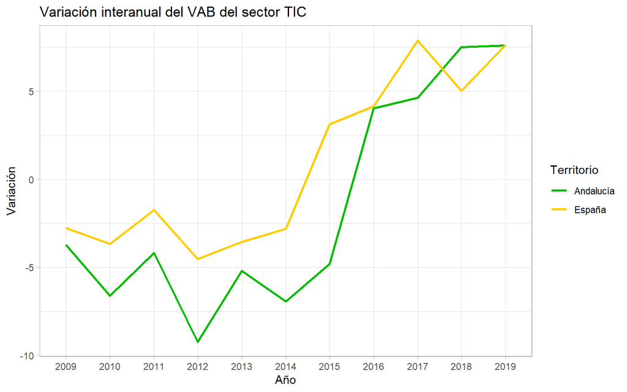

El peso que tiene cada uno de los **componentes del sector TIC** difiere bastante, marcando algunos de ellos la evolución del sector en su conjunto.  
La componente *Telecomunicaciones* deja de ser en 2019 la más importante en Andalucía (algo que ya había pasado en España 5 años atrás) representando según el último dato un peso del 44.4% del total del sector TIC (10 puntos menos en España). Es esta componente y su evolución descendente de los últimos años la que ha marcado el comportamiento del sector TIC en la región.  
Las Telecomunicaciones han sido sorpasadas por las *Actividades informáticas* que ya lideran el sector en España y que representan en Andalucía el 45.8% del sector TIC en la comunidad (y casi el 52.9% en España). Esta componente venía experimentado un crecimiento positivo continuado en los últimos años, siendo su variación respecto al año anterior de un 18.8 % (11.5% en España).  
El resto de componentes *Comercio al por mayor TIC* y *Fabricación TIC* han perdido peso en el último periodo, teniendo un peso relativo en 2019 de 6.6% y 3.2% respectivamente. En el caso de España los pesos se han mantenido estables (10.2% y 2.5% respectivamente).

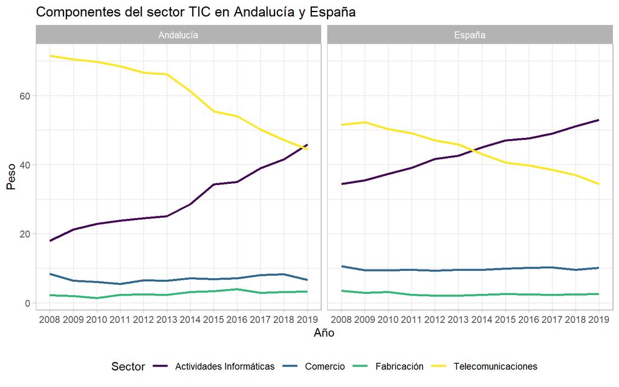

## Porcentaje del sector TIC respecto al PIB

El porcentaje del sector TIC en Andalucía respecto al PIB es del 1.56% en 2019 habiendo aumentado ligeramente (0.07 puntos porcentuales) respecto al año anterior. En España este porcentaje es del 3.13%.

Durante todo el periodo analizado se observa una tendencia negativa en la evolución del indicador, tanto en Andalucía como en España, si bien se aprecia una recuperación en los últimos años. La brecha entre los dos territorios ha aumentado a lo largo de este periodo situándose en la actualidad en 1.57 puntos porcentuales.

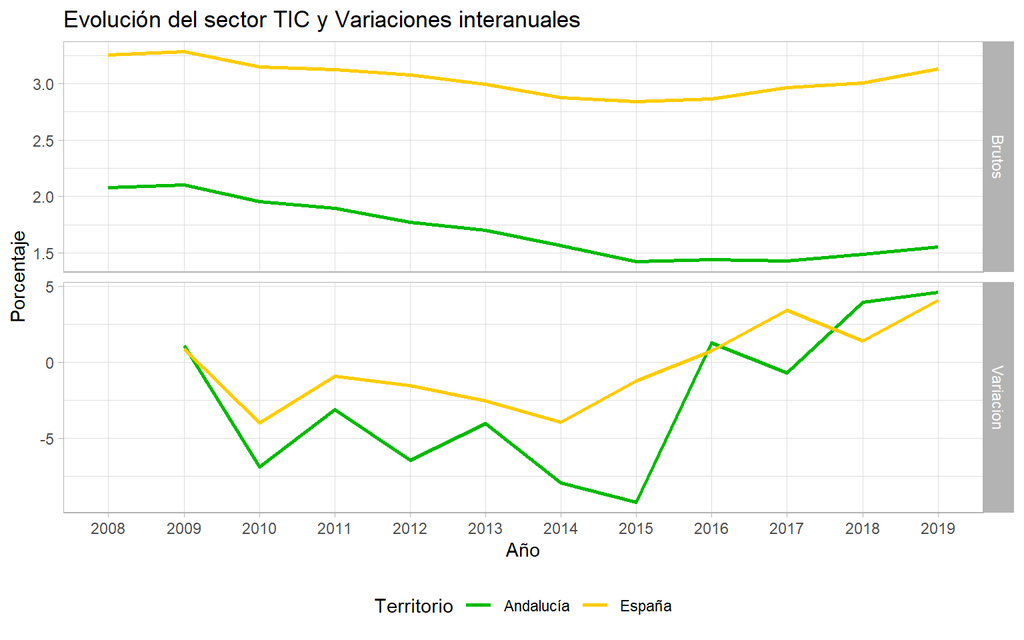

La aportación al PIB de cada **componente** es proporcional a su peso en el VAB del sector.  
La componente de las *Telecomunicaciones* representa un 0.69% del PIB y ha ido perdiendo peso en todo el periodo como ha sido comentado, peso que han ido ganando las *Actividades informáticas*, que representan el 0.71% del PIB. La componente *Comercio al por mayor TIC* representa un 0.1% del PIB regional y *Fabricación TIC* un 0.05%.

## Cifra de negocio

La cifra de negocio del sector TIC andaluz es de más de 6 425.4 millones de euros, habiendo aumentado respeto al año 2018 un 3.8%.

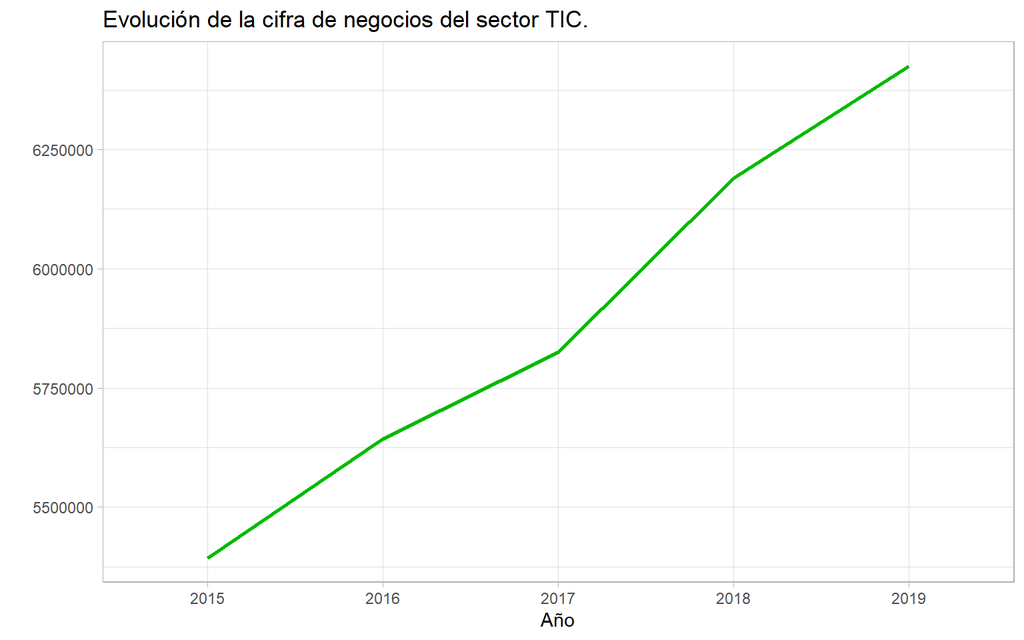

El peso que tiene cada una de las **componentes** del sector TIC también difiere bastante como ocurre con otros indicadores, estando la evolución del sector en su conjunto en clara dependencia de algunos sectores.

La principal componente como es de esperar es la de *Telecomunicaciones* representando un peso del 44.3% del total del sector TIC , y un 5.7% de la cifra de negocio del sector servicios. Su tendencia es descendente en relación al peso que tiene.  
El aumento en importancia de las *Actividades Informáticas* es también visible en este indicador, significando un 31.4% de la cifra de negocio del sector TIC y habiendo aumentado un 15.8% en el último año. Esta componente representa un 4% de la cifra de negocio del sector servicios en su conjunto.  
Las componentes *Comercio al por mayor TIC* y *Fabricación TIC* se mantienen también estables entorno al 19.4% y 4.9% respectivamente, con tendencia estable. La componente comercial representa el 1.2% de la cifra de negocios del sector comercial y la componente fabricación el 0.4% de la cifra de negocio del sector industrial.

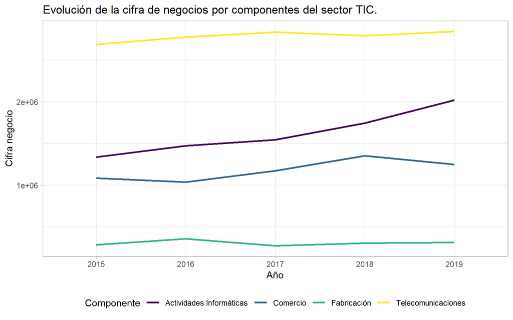

## Número de ocupados en el sector TIC

Según la Encuesta de Estructura Empresarial, el sector TIC de Andalucía cuenta en 2019 con unos 51 mil ocupados medios (incluyen asalariados y autónomos), siendo esta cifra cercana a los 528 mil para el conjunto de España. El último año disponible ha supuesto un aumento de un 7.5% en este indicador de ocupación en Andalucía (un 5.7% en España), manteniendo así la linea de alto crecimiento positivo de los últimos 6 años.

[figure not shown]

Por **componentes** se observa que las *Actividades Informáticas* son las que tienen un mayor porcentaje de ocupados, alcanzando el 66.2% del total de ocupados del sector. Las *Telecomunicaciones* suponen un 19% de la ocupación con una tendencia decreciente aunque menor del ritmo con el que está perdiendo peso respecto al PIB como hemos comentado. Las componentes de *Comercio al por mayor TIC* y *Fabricación TIC* tienen un peso relativo en la ocupación del sector del 10.4% y 4.4% respectivamente, con una tendencia descendente en la componente del comercio.

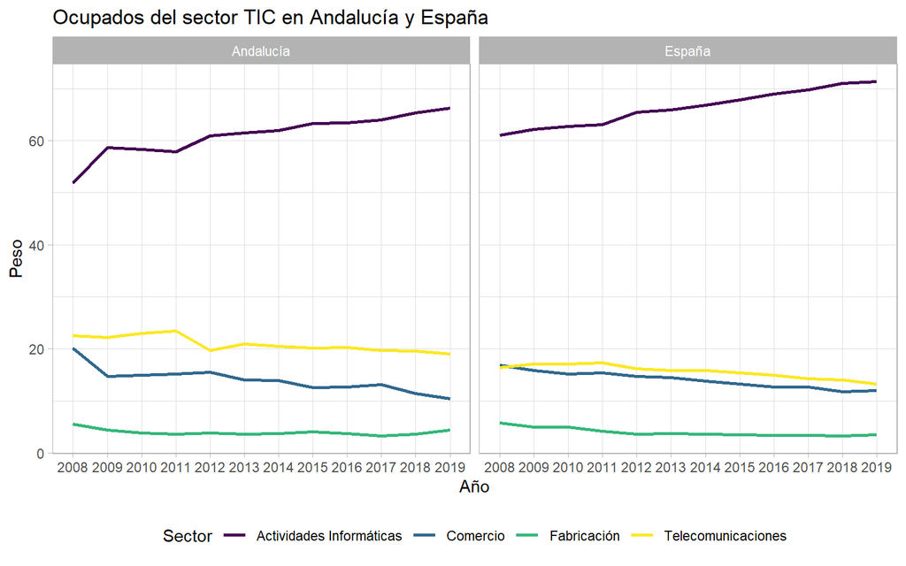

A partir de la Encuesta de Población Activa (EPA) también es posible aproximarse al número de ocupados cuya actividad entra dentro de los códigos seleccionados, El número absoluto deocupados de la EPA varía respecto al comentado de la Encuesta Estructural de Empresas tanto por efecto de la fuente como por los conceptos, ya que la EPA recoge al información a 3 dígitos de la CNAE, por lo que incorpora más códigos que los vistos para la Encuestra Estructura. Más interesante que el número de ocupados en si (64 mil según la EPA) es su perfil demográfico. El ocupado TIC según la EPA es un hombre (81%) de menos de 40 años (61%) de nacionalidad española (95.6%) y con estudios superiores (76.2%) que reside en alguna capital de provincia (41.6%)

## VAB por ocupado del sector TIC

Una medida de la productividad es la comparación del VAB con el número de ocupados, que podríamos identificar como el número de euros que genera cada trabajador.

Ante la evolución ligeramente creciente del VAB en los últimos años y el crecimiento mayor de la ocupación, este indicador de la productividad global del sector TIC muestra una tendencia decreciente, levemente creciente en los últimos años a nivel estatal. El VAB por ocupado en Andalucía toma en 2019 el valor de unos 53 mil euros (74 mil euros en España) habiendo experimentado un ligero aumento de un 0.1% durante el año 2019, resultado de una tendencia de decrecimientos cada vez menores de años anteriores. A nivel estatal, el crecimiento en 2019 ha sido positivo de un 1.81%, pero es una tendencia que tambien procede de crecimientos negativos de años anteriores (salvo 2017).

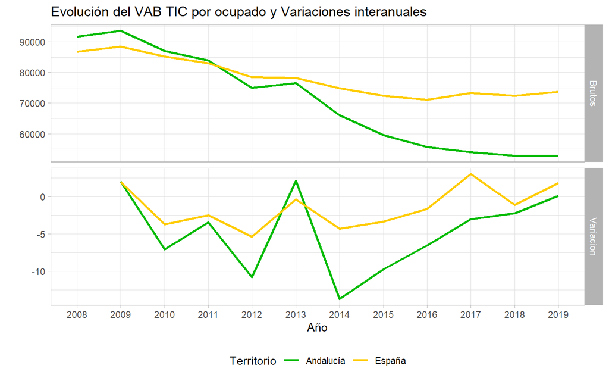

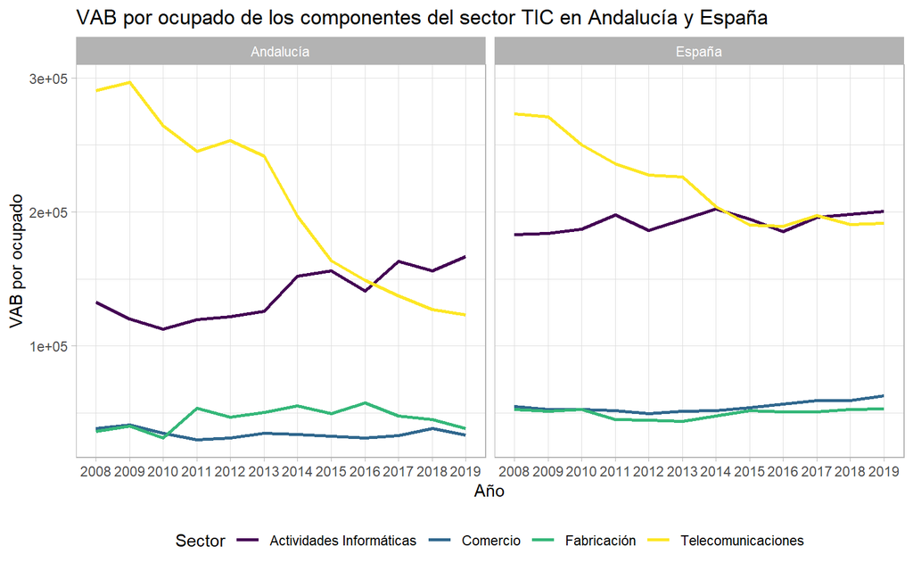

La productividad del sector TIC andaluz en su conjunto es de -28.3%, inferior a la de España. Por componentes ocurre lo mismo, todas las componentes presentan para Andalucía valores inferiores a los nacionales.

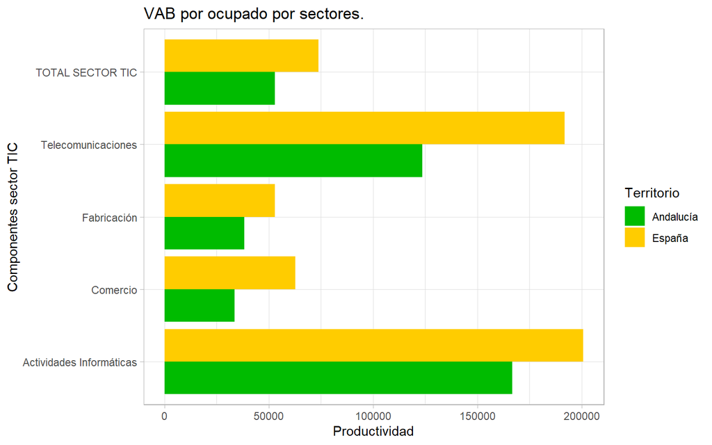

## Características del empleo

Las características del empleo en el sector TIC pueden analizarse con detalle a través de distintos indicadores recogidos en la Encuesta Estructural de Empresas.

### Tasa de asalariados

La *tasa de asalariados* indica el porcentaje de ocupados que son remunerados bajo un contrato, es decir son asalariados.

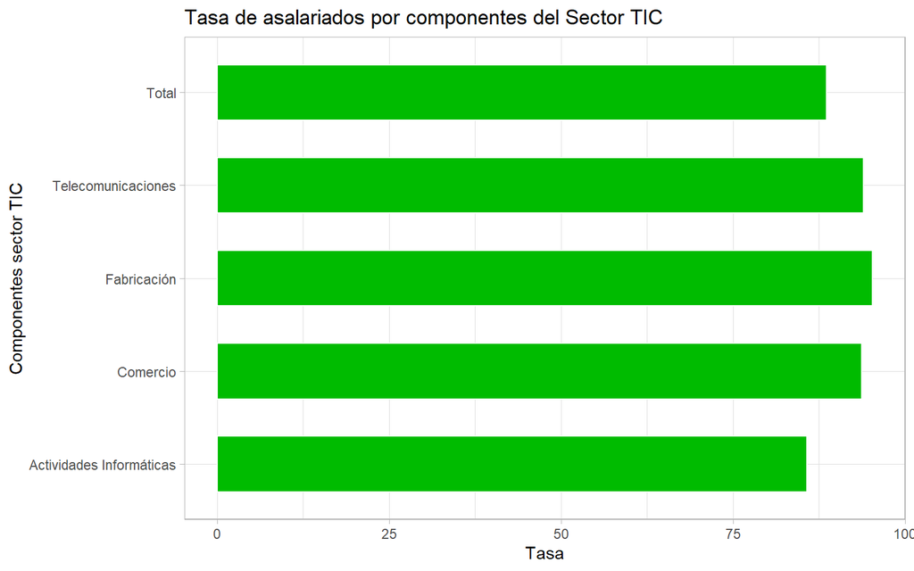

### Tipología de jornada laboral

En referencia a la tipología de jornada laboral el sector presenta en 2019 un porcentaje de asalariados con jornada parcial de un 9.1% porcentaje que es DE un 29.4% para el conjunto de la economía andaluza. Es decir el sector presenta un indicador de jornada parcial 20.3 puntos inferior a la economía en su conjunto.

Si la comparativa la hacemos por componentes los resultados también muestran importantes diferencias. Las más importantes se dan en las componentes de mayor peso ocupacional, *Actividades Informáticas* y *Telecomunicaciones* con diferencias unos 30 puntos respecto al conjuto del sector servicios.

La componente que tiene el porcentaje de asalariados con jornada parcial mayor es la componente de *Comercio al por mayor TIC*, con un valor de 13.7%, frente al 27.5% del valor del sector comercio. Este aspecto posiblemente esté relacionado con la menor presencia femenina en el sector TIC, como podrá verse en próximos indicadores, por supuesto sin ser la única causa, pero si que queda visible un comportamiento bastante distinto al conjunto de actividades de la economía.

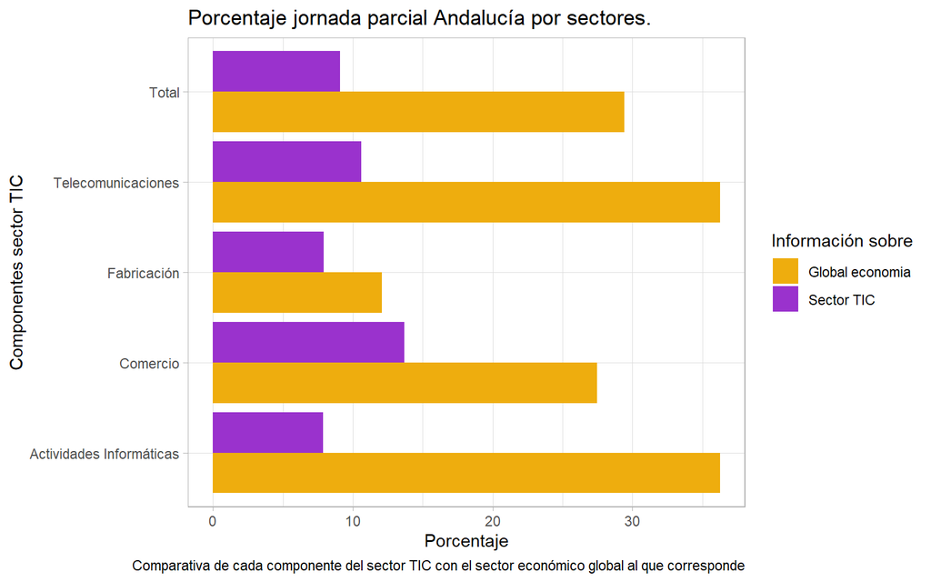

### Tasa de empleo femenina

La perspectiva de género del sector TIC puede analizarse a través de la *tasa femenina de empleo asalariado*. Este indicador muestra el porcentaje de mujeres remuneradas (independientemente de su tipo de jornada) respecto al total de remunerados en el sector TIC (o sus componentes).

Según este indicador, el porcentaje de mujeres en el sector TIC es de un 30.6% mientras que para el conjunto de actividades económicas es de un 43.3% . Es decir, si el mercado de trabajo se encuentra de por sí masculinizado, el sector TIC parece que lo está aún más.

El análisis por componentes del sector no hace más que reforzar esta idea, salvo en el caso de la *Fabricación TIC*, donde si parece que, estando el sector masculinizado (24.6% para el total de la industria) el porcentaje de mujeres en la componente Fabricación TIC es más alto que en el conjunto del sector, situándose 6.3 puntos por encima. En el resto de componentes, como ya se ha comentado, la diferencia con la tasa femenina de empleo de cada sector ronda los 15 puntos.

Revelador que la componente *Comercio al por mayor TIC* presenta unos valores inferiores al resto de componentes con un valor de 27.6%, perteneciendo a un sector económico muy feminizado (de hecho ronda el 50.3%)

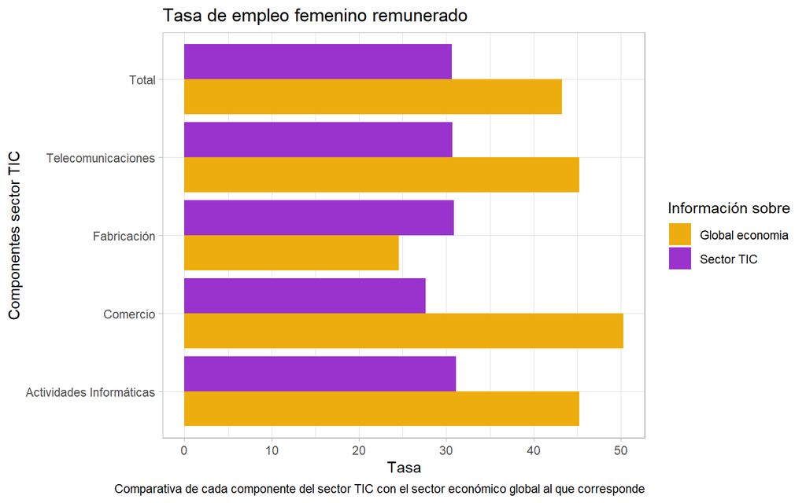

Los datos muestran por tanto una masculinización del sector TIC, que se hace aún más evidente en componentes pertenecientes a sectores donde la participación femenina es más alta.

### Remuneraciones salariales

Como indicador de las remuneraciones salariales se considera el *Salario medio*, calculado como el cociente entre los sueldos y salarios pagados a los remunerados y el número de ocupados medios. Este indicador permite un mejor análisis comparativo.

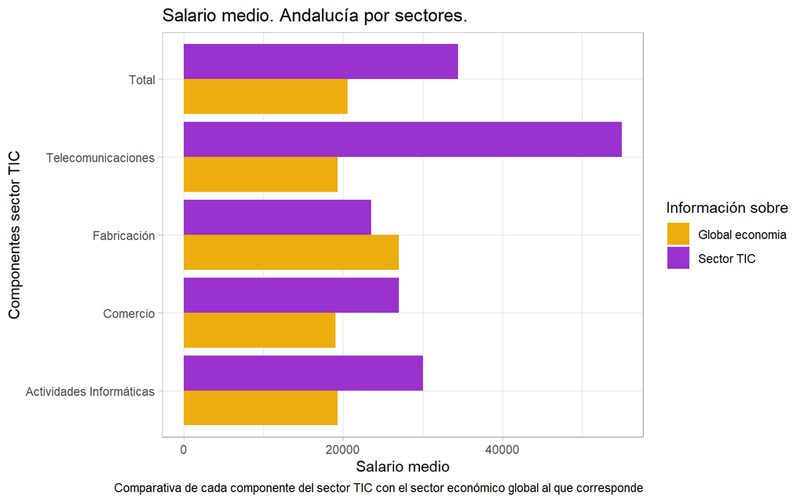

Podríamos concluir que en el sector TIC, seguramente por la necesidad de mayores estudios para poder estar dentro de él en la mayoría de los casos, ofrece unos salarios medios significativamente más elevados que el resto de actividades en su conjunto.

### Tasa de gasto de personal

Respecto al peso de las remuneraciones en los gastos empresariales la tasa de gasto de personal es un indicador que nos habla de ello ya que mide el porcentaje de la remuneración de asalariados frente al valor añadido a coste de los factores, es decir el peso de capital humano en el valor de la producción.

El indicador muestra que para el conjunto del sector TIC la tasa es superior al conjunto de la economía, situándose cerca 72.1% y el comportamiento por componentes es muy distinto. En todas las *componentes*, salvo en la de *Telecomunicaciones*, el peso del factor capital humano es superior a la media de su sector por unas cifras que suelen ser unos 25 puntos superiores a las de sus sector. En cambio la componente *Telecomunicaciones* presenta un comportamiento muy distinto. Su tasa de gasto de personal es más baja que el resto, de un 49.6%, es decir de cada 2 euros de valor generado 1 van destinados a remunerar al personal (hay que recordar además que su salario medio es el más elevado). Podría concluirse que es una componente más intensiva en otros factores (tecnología, software, hardware...).

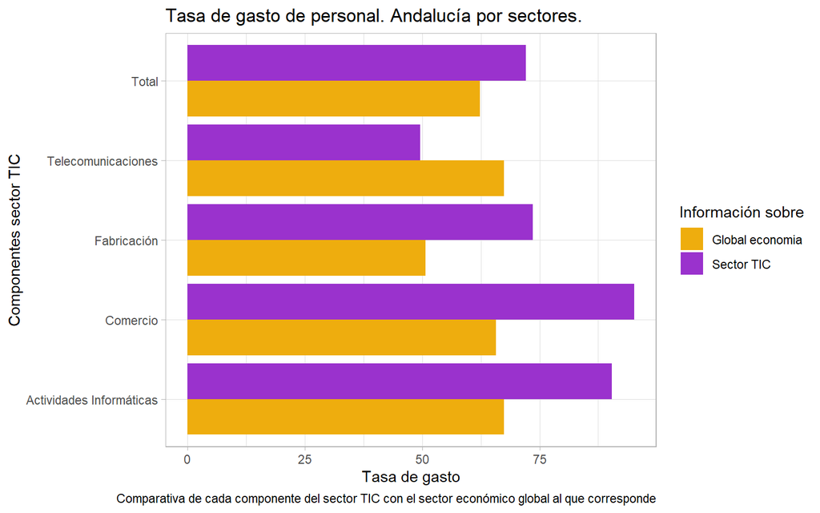

## Número de empresas del sector TIC

El número de empresas del sector TIC con locales ubicados en Andalucía es de 8 585, cifra que ha aumentado un 1.7% en el último año, y que sigue una senda ascendente de crecimiento, al igual que el resto del territorio nacional.

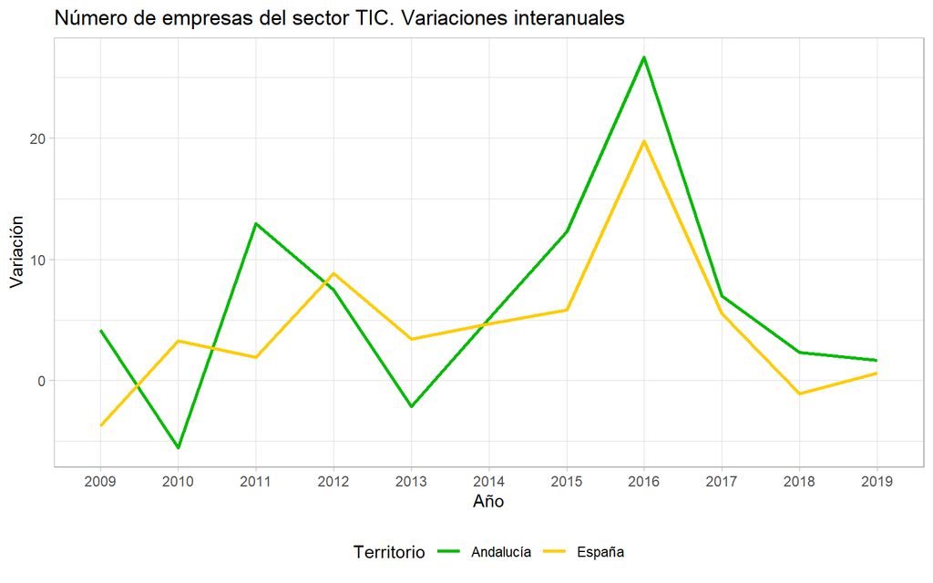

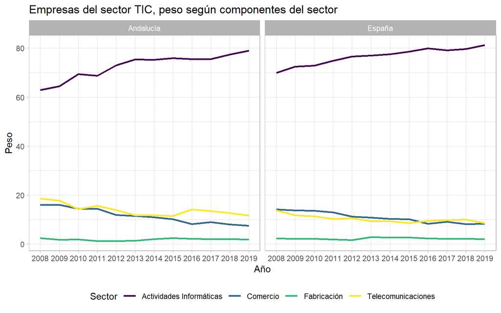

## Tamaño medio de las empresas TIC

El tamaño medio de las empresas del sector TIC en Andalucía es de 5.9 ocupados por empresa, frente a los 7.6 ocupados por empresa en España. La evolución en el tiempo ha sido una reducción generalizada en este indicador promedio al haber aumentado el número de empresas en mayor grado que el de ocupados hasta el año 2017 donde el indicador ha comenzado a aumentar tanto en Andalucía como en el resto de España.

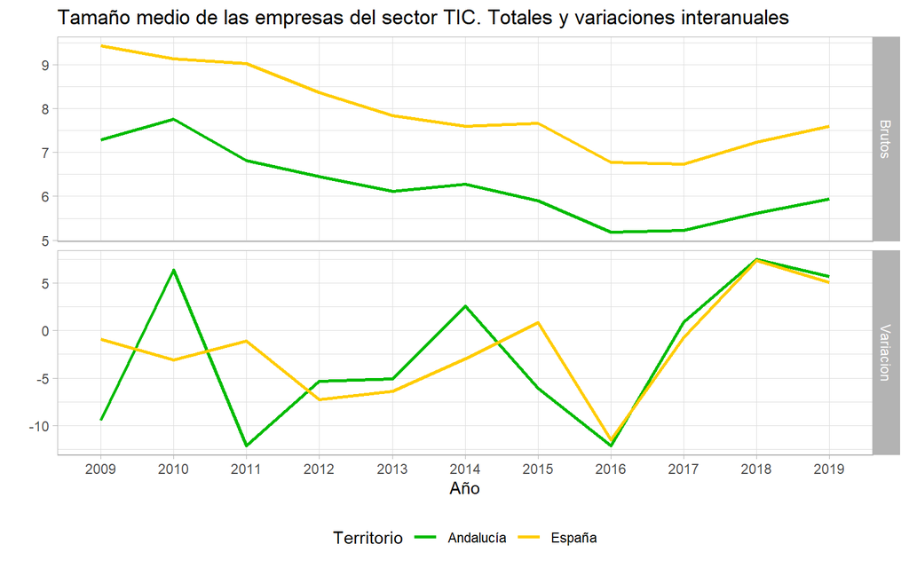

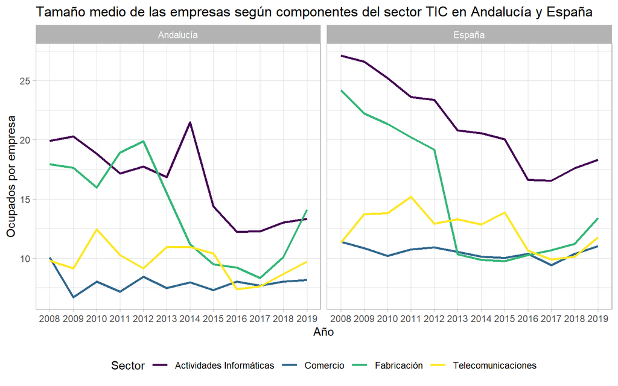

## Conclusiones

El sector TIC considerado en la definición está formado por una parte industrial (la fabricación de la tecnología), otra comercial (con la venta al por mayor de la misma) y por último una serie de actividades de servicios relacionadas con las actividades informáticas y telecomunicaciones que se consideran aparte como servicio dada su importancia y su particularidad.

Respecto al número de ocupados, según la Encuesta Estructural de Empresas, representan el *2,9%* de los ocupados totales (de nuevo por debajo de España con el *4,2%*) si bien el crecimiento en los últimos años ha sido positivo (último año 7.5) y superiores en muchos casos al conjunto nacional. Aún así la productividad media (VAB por ocupado) es inferior a la nacional presentando una fuerte trayectoria descendente.

La sector TIC muestra una tasa de asalariados del 88.6% y tasa de parcialidad en la jornada del 9.1%, inferiores en ambos casos a la tasa total. La presencia femenina en el sector TIC es de un 30.6% mientras que para el conjunto de actividades económicas es de un 43.3% porcentaje que varía mucho según la componente considerada, pero en cualquier caso inferior a las tasas de feniminzación del conjunto y de cada uno de los sectores económicos.

Las remuneraciones salariales del sector TIC son en general superiores a las remuneraciones medias del conjunto de la economía, algo que ocurre salvo en Fabricación TIC, destacando al respecto por elevadas las remuneraciones del sector de las Telecomunicaciones. Es además un sector muy intensivo en capital humano, como muestran los indicadores de gasto de personal, con la salvedad de la componente Telecomunicaciones.